# GEN-I: Nelinearne transakcije

Projekt pri predmetu: Matematika z racunalnikom

Anja Trobec

Maj 2022

## NAVODILA ZA IZDELAVO PROJEKTA

Imamo mesecno nelinearno transakcijo za elektricno energijo, kjer se lahko znotraj dolocenih omejitev za vsako uro znotraj meseca dobave lastnik opcijskosti odloci, koliko el. energije bo prevzeli/dobavil. Ovrednotimo jo napram mnozici cenovnih scenarijev, tako da za vsak cenovni scenarij dobimo njen profit. Cenovni scenariji so mozne prihodnje cene dobave, oblikovani tako, da ustrezno popisejo verjetnostno porazdelitev prihodnje cene v smislu njene srednje vrednosti in standardne deviacije (volatilnosit). Za to transakcijo zelimo poiskati njen ekvivalent standardne Evropske opcije. Kaksni so parametri ekvivalenta te opcije, kot kolicina, cena (strike), stran (nakup/prodaja) in tip (call/put) opcije?

## TEORETICNI UVOD

Moja glavna naloga je poiskati Evropsko opcijo, ki se najbolje pribliza transakciji predstavljeni v podatkih. Vhodni podatki so pari, v katerih prva komponenta predstavlja ceno in druga profit pri dani ceni.

Evropski opciji, ki bo ekvivalentna transakciji, je potrebno dolociti parametre. To so:

- v naprej dogovorjena izvrsilna cena (angl. strike price),
- kolicina in
- placana ali prejeta premija.

Dolociti moramo **tip opcije**. Lahko gre za:

- **nakupno opcijo** (*angl. call option*) ali
- **prodajno opcijo** (*angl. put option*).

Znotraj obeh tipov opcij, locimo se pozicijo, ki jo zavzamemo. Lahko smo v vlogi izdajatelja opcije (*angl. option writer*) in v tem primeru **opcijo prodamo** ali pa **opcijo kupimo** in s tem postanemo lastnik opcije (*angl. option buyer*).

S tem smo prisli do stirih razlicnih situacij, med katerimi iscemo tisto, ki najbolje opise dano transakcijo. Podrobneje si poglejmo vsako izmed moznih izbir.

#### NAKUP EVROPSKE NAKUPNE OPCIJE

Nakupna opcija podeljuje lastniku pravico za nakup dolocenega financnega instrumenta (angl. *underlying asset*) po vnaprej doloceni izvrsilni ceni na dolocen dan (kadar govorimo o Evropski opciji) ali do dolocenega dne (kadar imamo opravka z Amerisko opcijo). Lastniku nakupna opcija ne predstavlja obveznosti, pac pa priloznost (recemo, da mu nudi opcijskost), da opcijo izvrsi v primeru, ce cena financnega instrumenta na trgu naraste. Za nakupno opcijo recemo, da je:

- **in the money** - ce je cena financnega instrumenta nad izvrsilno ceno,
- **at the money** - ce sta cena financnega instrumenta in izvrsilna cena enaki,
- **put of the money** - ce je cena financnega instumenta pod izvrsilno ceno.

Opazimo, da ima kupec evropske nakupne opcije neomejen dobicek in na drugi strani izgubo omejeno s premijo. Drugace povedano, najvec kar lahko kupec izgubi je premija, ki jo placa za nakup opcije v primeru, da opcije ne izvrsi.

#### NAKUP EVROPSKE PRODAJNE OPCIJE

Prodajna opcija podeljuje lastniku pravico za prodajo dolocenega financnega instrumenta (angl. *underlying asset*) po vnaprej doloceni izvrsilni ceni na dolocen dan (kadar govorimo o Evropski opciji) ali do dolocenega dne (kadar imamo opravka z Amerisko opcijo). Lastniku nakupna opcija ne predstavlja obveznosti, pac pa priloznost (recemo, da mu nudi opcijskost), da opcijo izvrsi v primeru, ce cena financnega instrumenta na trgu pade. Za nakupno opcijo recemo, da je:

- **in the money** - ce je cena financnega instrumenta pod izvrsilno ceno,
- **at the money** - ce sta cena financnega instrumenta in izvrsilna cena enaki,
- **put of the money** - ce je cena financnega instumenta nad izvrsilno ceno.

#### PRODAJA EVROPSKE NAKUPNE OPCIJE

Zdaj se postavimo v vlogo izdajatelja opcije. S tem ko opcijo prodamo, se zavezemo k izplacilu v primeru, da kupec opcijo izvrsi. Torej je v tem primeru dobicek navzgor omejen s prejeto premijo in izguba navzdol neomejena v primeru, da cena na trgu naraste.

#### PRODAJA EVROPSKE PRODAJNE OPCIJE

Poglejmo si izplacila vseh stirih opcij na spodnji sliki.

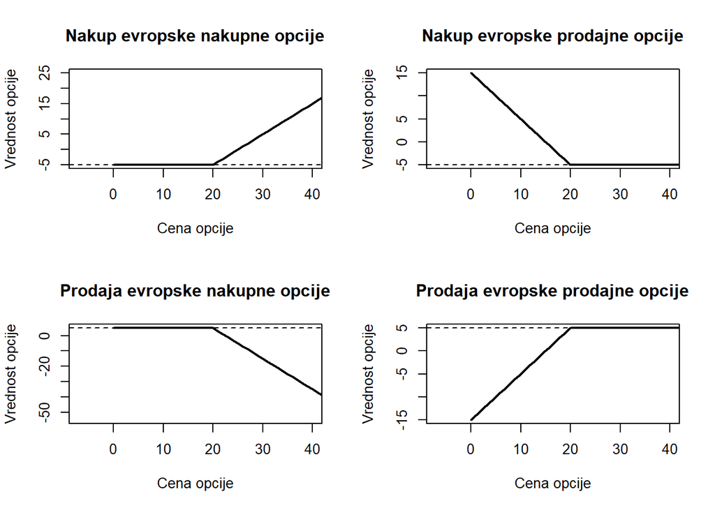

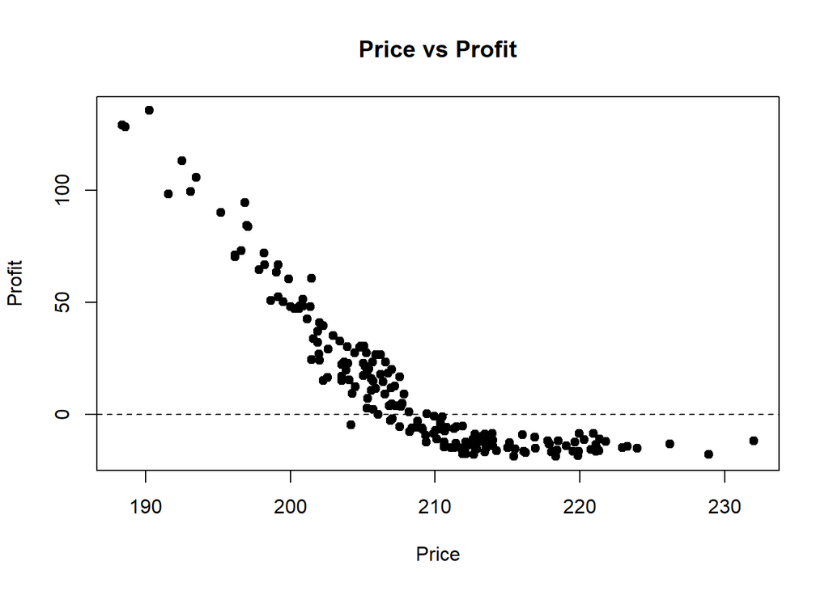

Iz slike je jasno razvidno, da gre za nakup evropske prodajne opcije. Za dolocitev izvrsilne cene, kolicine in premije moramo najti ustrezno aproksimacijo z dvema premicama. Ti dve premici imata doloceno obliko, ena izmed njiju je vselej vodoravna, druga pa posevna s pozitivnim ali negativnim naklonom, seveda odvisno od vrste opcije.

```
##           Price       Profit
## 192  188,385345  129165,0436
## 191 188,6013962  128361,5142
## 190 190,2728982  135612,8448
## 189 191,5932288  98347,77853
## 188 192,5263105  113098,7073
## 187 193,0971056  99554,40251
## 186  193,480249  105798,7043
## 185 195,2034768   90183,0697
## 184 196,1771199  70430,19947
## 183  196,177681  71133,79931
## 182 196,6029908  73202,68519
## 181 196,8722731  94604,22717
## 180 196,9934786  84411,72739
## 179 197,0935844  83822,44611
```

[output cut: 178 more lines]

```
## [1] -0.8672938
```

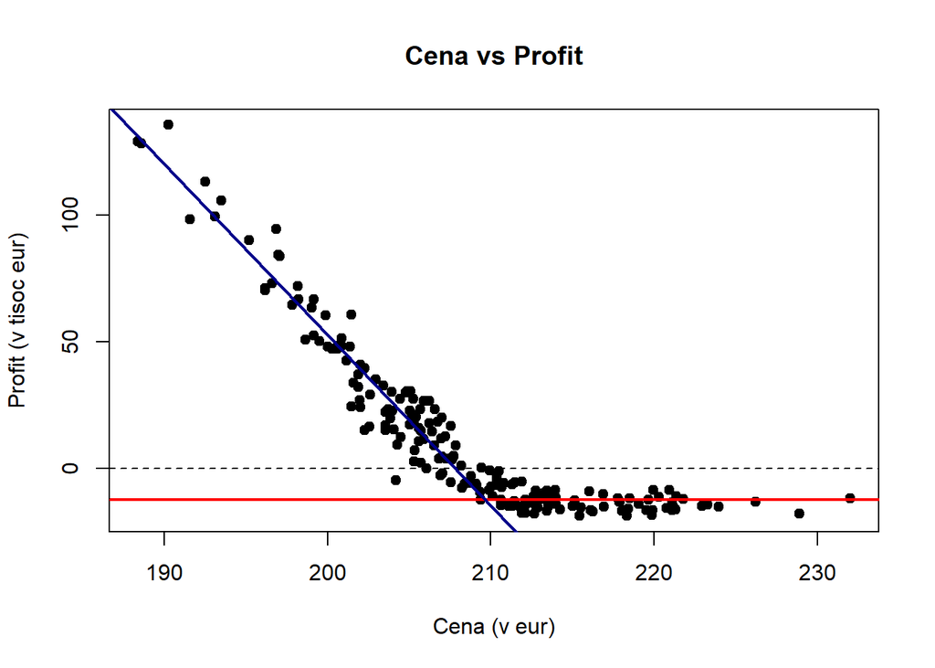

```
## [1] "Gre za nakup put opcije."
## [1] "Priblizek za izvrsilno ceno opcije je 209.3690697, za premijo pa -12.1629052."
```